# Tugas Analisis Deret Waktu: Proses MA(2), AR(2), dan ARMA(2,2)

```r
library(TSA)
```

# Soal 1: Proses MA(2)

## 1.1 Pembangkitan Data

Model MA(2) yang digunakan:
$$Y_t = e_t +
\theta_1 e_{t-1} + \theta_2 e_{t-2}$$

### a. Manual

```r
set.seed(123)
n <- 300
theta1 <- 0.4
theta2 <- 0.6

e <- rnorm(n + 2, mean = 0, sd = 1)

Yt_ma2_manual <- numeric(n)
for (t in 1:n) {
  Yt_ma2_manual[t] <- e[t + 2] + theta1 * e[t + 1] + theta2 * e[t]
}

ma2_manual <- ts(Yt_ma2_manual)
head(ma2_manual)
```

```
## Time Series:
## Start = 1
## End = 6
## Frequency = 1
## [1]  1.13035193  0.55588522  1.09271608  1.80908512  1.22451484 -0.05165576
```

### b. Menggunakan `arima.sim`

```r
set.seed(123)
ma2_sim <- arima.sim(model = list(ma = c(theta1, theta2)), n = n)
head(ma2_sim)
```

```
## Time Series:
## Start = 1
## End = 6
## Frequency = 1
## [1]  1.13035193  0.55588522  1.09271608  1.80908512  1.22451484 -0.05165576
```

## 1.2 Plot Time Series, ACF, PACF, dan EACF

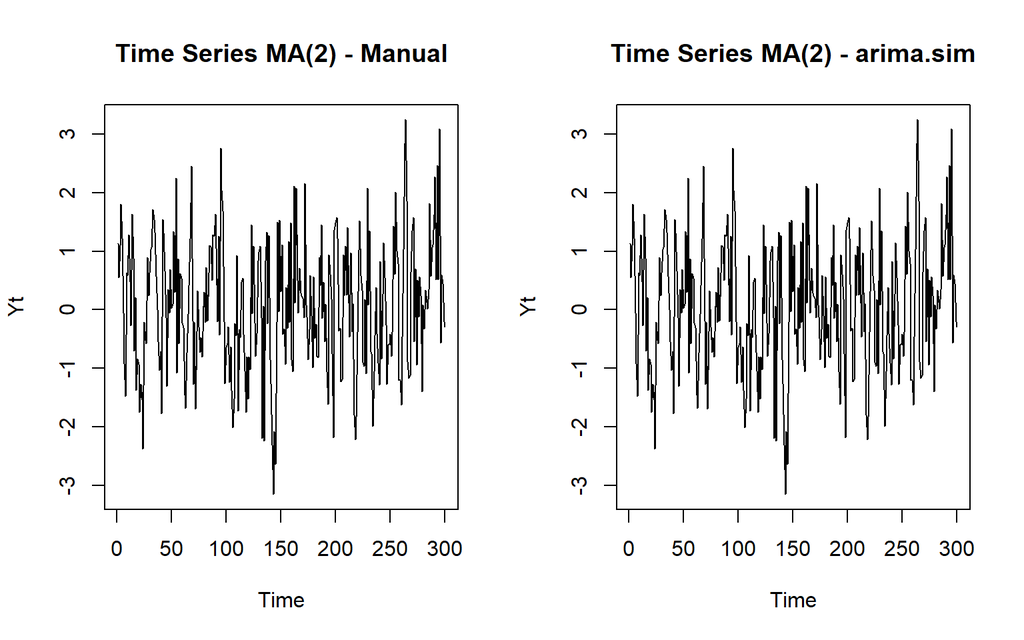

```r
par(mfrow = c(1, 2))
ts.plot(ma2_manual, main = "Time Series MA(2) - Manual", ylab = "Yt")
ts.plot(ma2_sim, main = "Time Series MA(2) - arima.sim", ylab = "Yt")
```

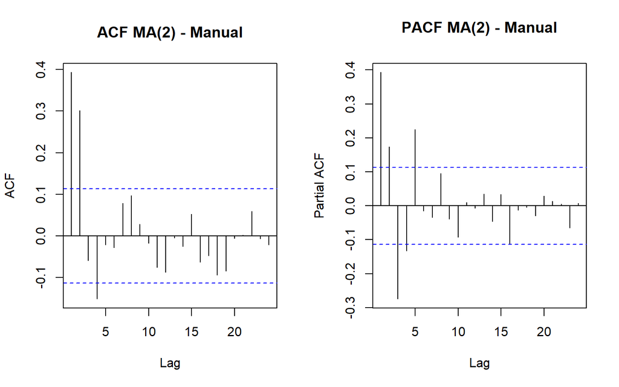

```r
par(mfrow = c(1, 2))
acf(ma2_manual, main = "ACF MA(2) - Manual")
pacf(ma2_manual, main = "PACF MA(2) - Manual")
```

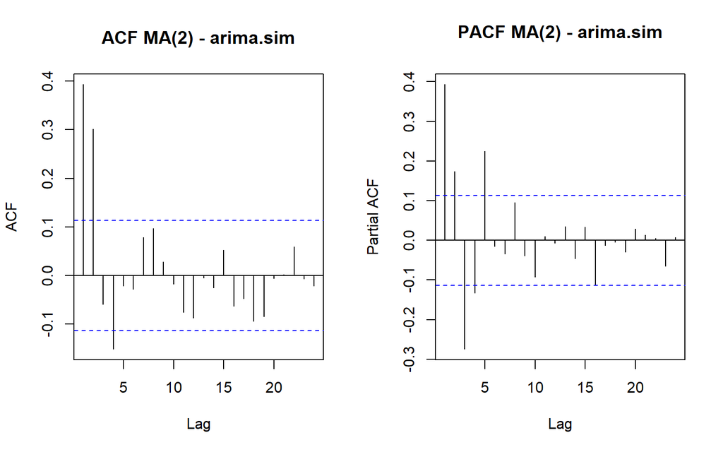

```r
par(mfrow = c(1, 2))
acf(ma2_sim, main = "ACF MA(2) - arima.sim")
pacf(ma2_sim, main = "PACF MA(2) - arima.sim")
```

```r
cat("EACF - Data Manual\n")
```

```
## EACF - Data Manual
```

```r
eacf(ma2_manual)
```

```
## AR/MA
##   0 1 2 3 4 5 6 7 8 9 10 11 12 13
## 0 x x o x o o o o o o o  o  o  o
## 1 x x x x o o o o o o o  o  o  o
## 2 x x o x o o o o o o o  o  o  o
## 3 x x o o x o o o o o o  o  o  o
## 4 x x x x x o o o o o o  o  o  o
## 5 o x x x x o o o o o o  o  o  o
## 6 x o x x o o o o o o o  o  o  o
## 7 x x o x x o o o o o o  o  o  o
```

```r
cat("\nEACF - Data arima.sim\n")
```

```
##
## EACF - Data arima.sim
```

```r
eacf(ma2_sim)
```

```
## AR/MA
##   0 1 2 3 4 5 6 7 8 9 10 11 12 13
## 0 x x o x o o o o o o o  o  o  o
## 1 x x x x o o o o o o o  o  o  o
## 2 x x o x o o o o o o o  o  o  o
## 3 x x o o x o o o o o o  o  o  o
## 4 x x x x x o o o o o o  o  o  o
## 5 o x x x x o o o o o o  o  o  o
## 6 x o x x o o o o o o o  o  o  o
## 7 x x o x x o o o o o o  o  o  o
```

**Identifikasi kestasioneran:** Proses MA berorde berapa pun (finite order) **selalu stasioner**, karena merupakan kombinasi linear terbatas dari white noise. Hal ini juga terlihat dari plot time series yang berfluktuasi di sekitar rata-rata konstan (mendekati 0) tanpa tren, serta plot ACF yang terputus setelah lag ke-2.

## 1.3 Scatterplot $Y_t$ vs $Y_{t-1}$, $Y_{t-2}$, $Y_{t-3}$

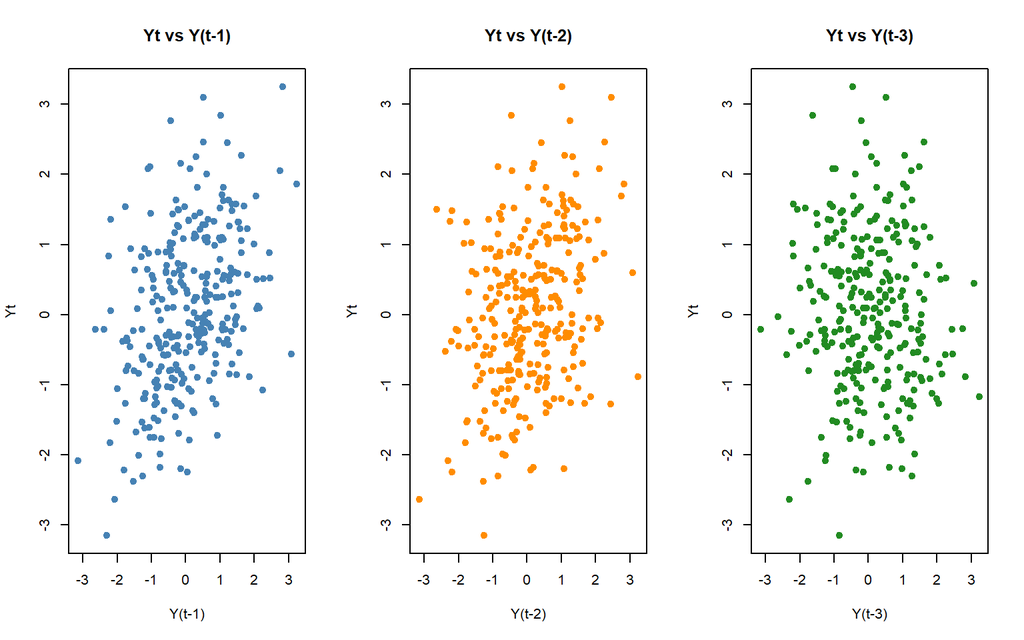

```r
Yt <- as.numeric(ma2_manual)
n_y <- length(Yt)

par(mfrow = c(1, 3))
plot(Yt[1:(n_y-1)], Yt[2:n_y], xlab = "Y(t-1)", ylab = "Yt",
     main = "Yt vs Y(t-1)", pch = 19, col = "steelblue")
plot(Yt[1:(n_y-2)], Yt[3:n_y], xlab = "Y(t-2)", ylab = "Yt",
     main = "Yt vs Y(t-2)", pch = 19, col = "darkorange")
plot(Yt[1:(n_y-3)], Yt[4:n_y], xlab = "Y(t-3)", ylab = "Yt",
     main = "Yt vs Y(t-3)", pch = 19, col = "forestgreen")
```

## 1.4 Autokorelasi: Empiris vs Teoritis

**Autokorelasi empiris (dari data bangkitan):**

```r
acf_ma2_manual <- as.numeric(acf(ma2_manual, plot = FALSE, lag.max = 5)$acf)
acf_ma2_sim    <- as.numeric(acf(ma2_sim, plot = FALSE, lag.max = 5)$acf)

cat("Panjang acf_ma2_manual:", length(acf_ma2_manual), "\n")
```

```
## Panjang acf_ma2_manual: 5
```

```r
cat("Panjang acf_ma2_sim   :", length(acf_ma2_sim), "\n")
```

```
## Panjang acf_ma2_sim   : 5
```

```r
lag_len <- min(length(acf_ma2_manual), length(acf_ma2_sim))

data.frame(
  Lag = 0:(lag_len - 1),
  ACF_Manual = round(acf_ma2_manual[1:lag_len], 4),
  ACF_arima.sim = round(acf_ma2_sim[1:lag_len], 4)
)
```

```
##   Lag ACF_Manual ACF_arima.sim
## 1   0     0.3929        0.3929
## 2   1     0.3015        0.3015
## 3   2    -0.0587       -0.0587
## 4   3    -0.1513       -0.1513
## 5   4    -0.0211       -0.0211
```

**Autokorelasi teoritis MA(2):**

Untuk proses MA(2), rumus autokorelasi teoritisnya adalah:
$$\rho_1 = \frac{\theta_1 +
\theta_1\theta_2}{1+\theta_1^2+\theta_2^2}, \qquad
\rho_2 = \frac{\theta_2}{1+\theta_1^2+\theta_2^2}, \qquad
\rho_k = 0 \text{ untuk } k \geq 3$$

```r
rho1_ma2 <- (theta1 + theta1 * theta2) / (1 + theta1^2 + theta2^2)
rho2_ma2 <- theta2 / (1 + theta1^2 + theta2^2)

cat("rho1 (teoritis) =", round(rho1_ma2, 4), "\n")
```

```
## rho1 (teoritis) = 0.4211
```

```r
cat("rho2 (teoritis) =", round(rho2_ma2, 4), "\n")
```

```
## rho2 (teoritis) = 0.3947
```

```r
cat("rho_k = 0 untuk k >= 3\n\n")
```

```
## rho_k = 0 untuk k >= 3
```

```r
cat("Verifikasi dengan ARMAacf():\n")
```

```
## Verifikasi dengan ARMAacf():
```

```r
ARMAacf(ma = c(theta1, theta2), lag.max = 5)
```

```
##         0         1         2         3         4         5
## 1.0000000 0.4210526 0.3947368 0.0000000 0.0000000 0.0000000
```

# Soal 2: Proses AR(2)

## 2.1 Pembangkitan Data

Model AR(2) yang digunakan mengikuti bentuk:
$$Y_t = \phi_1 Y_{t-1} + \phi_2 Y_{t-2} +
e_t$$

### a. Manual

```r
set.seed(123)
n <- 300
phi1 <- 0.5
phi2 <- 0.2
burn_in <- 50
e <- rnorm(n + burn_in, mean = 0, sd = 1)
Yt_ar2_manual <- numeric(n + burn_in)

Yt_ar2_manual[1] <- e[1]
Yt_ar2_manual[2] <- e[2]

for (t in 3:(n + burn_in)) {
  Yt_ar2_manual[t] <- phi1 * Yt_ar2_manual[t-1] + phi2 * Yt_ar2_manual[t-2] + e[t]
}

ar2_manual <- ts(Yt_ar2_manual[(burn_in + 1):(n + burn_in)])
head(ar2_manual)
```

```
## Time Series:
## Start = 1
## End = 6
## Frequency = 1
## [1] 0.3696154 0.1648265 0.1134658 1.4583005 0.5260724 2.0711669
```

### b. Menggunakan `arima.sim`

```r
set.seed(123)
ar2_sim <- arima.sim(model = list(ar = c(phi1, phi2)), n = n)
head(ar2_sim)
```

```
## Time Series:
## Start = 1
## End = 6
## Frequency = 1
## [1] -2.9518714 -1.0047928 -0.9393975 -1.8087943  0.1615383  0.1454745
```

## 2.2 Plot Time Series, ACF, PACF, dan EACF

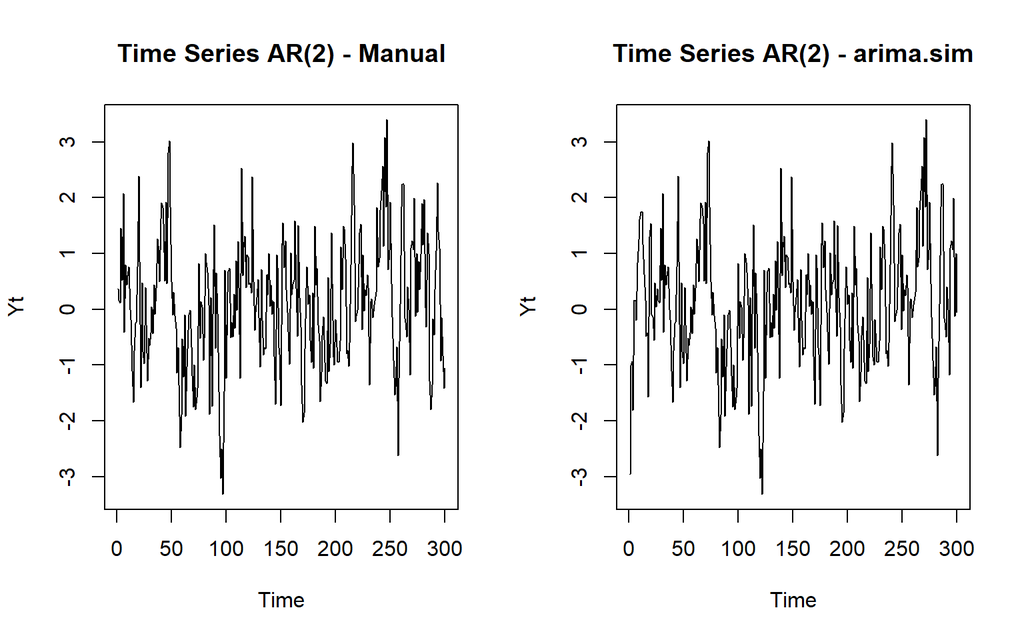

```r
par(mfrow = c(1, 2))
ts.plot(ar2_manual, main = "Time Series AR(2) - Manual", ylab = "Yt")
ts.plot(ar2_sim, main = "Time Series AR(2) - arima.sim", ylab = "Yt")
```

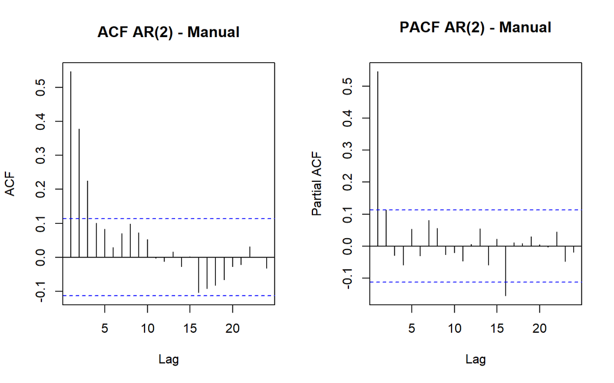

```r
par(mfrow = c(1, 2))
acf(ar2_manual, main = "ACF AR(2) - Manual")
pacf(ar2_manual, main = "PACF AR(2) - Manual")
```

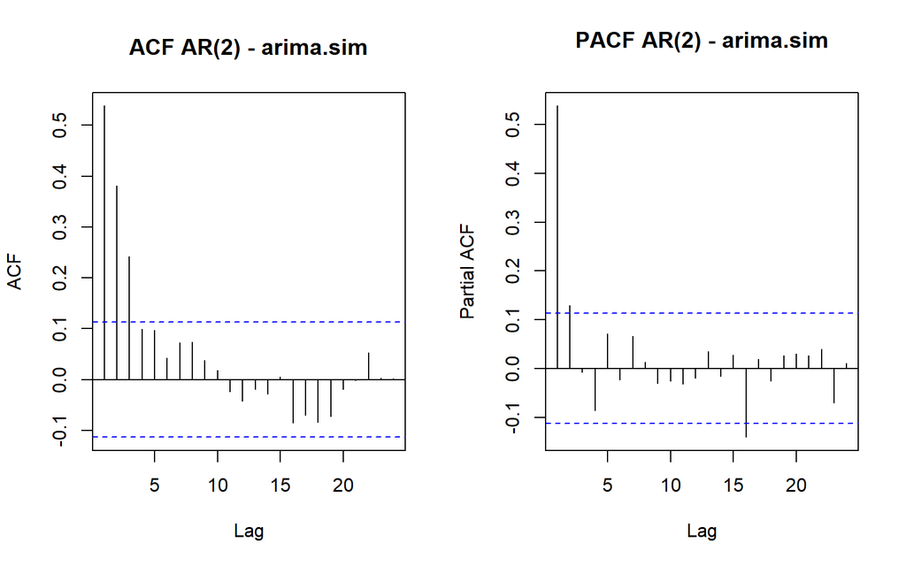

```r
par(mfrow = c(1, 2))
acf(ar2_sim, main = "ACF AR(2) - arima.sim")
pacf(ar2_sim, main = "PACF AR(2) - arima.sim")
```

```r
cat("EACF - Data Manual\n")
```

```
## EACF - Data Manual
```

```r
eacf(ar2_manual)
```

```
## AR/MA
##   0 1 2 3 4 5 6 7 8 9 10 11 12 13
## 0 x x x o o o o o o o o  o  o  o
## 1 x o o o o o o o o o o  o  o  o
## 2 x x o o o o o o o o o  o  o  o
## 3 x x o o o x o o o o o  o  o  o
## 4 x o o o o x o o o o o  o  o  o
## 5 x x o x o o o o o o o  o  o  o
## 6 x x o x x o o o o o o  o  o  o
## 7 x x o x x o o o o o o  o  o  o
```

```r
cat("\nEACF - Data arima.sim\n")
```

```
##
## EACF - Data arima.sim
```

```r
eacf(ar2_sim)
```

```
## AR/MA
##   0 1 2 3 4 5 6 7 8 9 10 11 12 13
## 0 x x x o o o o o o o o  o  o  o
## 1 x o o x o o o o o o o  o  o  o
## 2 o o o o o o o o o o o  o  o  o
## 3 o x o o o o o o o o o  o  o  o
## 4 x x o o o x o o o o o  o  o  o
## 5 x x o x o o o o o o o  o  o  o
## 6 x x o x x o o o o o o  o  o  o
## 7 x x x x x o o o o o o  o  o  o
```

**Identifikasi kestasioneran:** Syarat stasioner untuk AR(2) adalah akar-akar dari persamaan karakteristik $1 - \phi_1 z - \phi_2 z^2 = 0$ berada di luar lingkaran satuan (modulusnya > 1).

```r
akar <- polyroot(c(1, -phi1, -phi2))
akar
```

```
## [1]  1.311738+0i -3.811738+0i
```

```r
Mod(akar)
```

```
## [1] 1.311738 3.811738
```

Karena modulus seluruh akar lebih besar dari 1, maka proses AR(2) dengan $\phi_1 = 0.5$ dan $\phi_2 = 0.2$ **stasioner**. Hal ini juga dapat dilihat dari plot ACF yang menurun (*decay*) secara eksponensial, dan plot PACF yang *cut off* setelah lag ke-2.

## 2.3 Scatterplot $Y_t$ vs $Y_{t-1}$, $Y_{t-2}$, $Y_{t-3}$

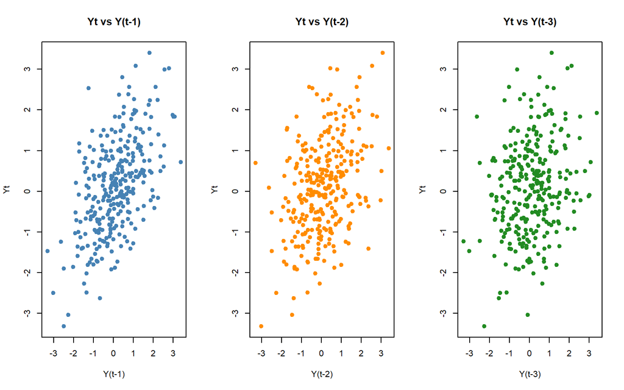

```r
Yt <- as.numeric(ar2_manual)
n_y <- length(Yt)

par(mfrow = c(1, 3))
plot(Yt[1:(n_y-1)], Yt[2:n_y], xlab = "Y(t-1)", ylab = "Yt",
     main = "Yt vs Y(t-1)", pch = 19, col = "steelblue")
plot(Yt[1:(n_y-2)], Yt[3:n_y], xlab = "Y(t-2)", ylab = "Yt",
     main = "Yt vs Y(t-2)", pch = 19, col = "darkorange")
plot(Yt[1:(n_y-3)], Yt[4:n_y], xlab = "Y(t-3)", ylab = "Yt",
     main = "Yt vs Y(t-3)", pch = 19, col = "forestgreen")
```

## 2.4 Autokorelasi: Empiris vs Teoritis

**Autokorelasi empiris (dari data bangkitan):**

```r
acf_ar2_manual <- as.numeric(acf(ar2_manual, plot = FALSE, lag.max = 5)$acf)
acf_ar2_sim    <- as.numeric(acf(ar2_sim, plot = FALSE, lag.max = 5)$acf)

cat("Panjang acf_ar2_manual:", length(acf_ar2_manual), "\n")
```

```
## Panjang acf_ar2_manual: 5
```

```r
cat("Panjang acf_ar2_sim   :", length(acf_ar2_sim), "\n")
```

```
## Panjang acf_ar2_sim   : 5
```

```r
lag_len <- min(length(acf_ar2_manual), length(acf_ar2_sim))

data.frame(
  Lag = 0:(lag_len - 1),
  ACF_Manual = round(acf_ar2_manual[1:lag_len], 4),
  ACF_arima.sim = round(acf_ar2_sim[1:lag_len], 4)
)
```

```
##   Lag ACF_Manual ACF_arima.sim
## 1   0     0.5461        0.5384
## 2   1     0.3777        0.3812
## 3   2     0.2248        0.2425
## 4   3     0.1007        0.0998
## 5   4     0.0833        0.0972
```

**Autokorelasi teoritis AR(2):**

Autokorelasi teoritis AR(2):
$$\rho_1 =
\frac{\phi_1}{1-\phi_2}, \qquad \rho_k = \phi_1 \rho_{k-1} + \phi_2
\rho_{k-2}, \; k \geq 2$$

```r
rho1_ar2 <- phi1 / (1 - phi2)

rho_ar2 <- numeric(6)
rho_ar2[1] <- 1
rho_ar2[2] <- rho1_ar2
for (k in 3:6) {
  rho_ar2[k] <- phi1 * rho_ar2[k-1] + phi2 * rho_ar2[k-2]
}

data.frame(Lag = 0:5, ACF_Teoritis = round(rho_ar2, 4))
```

```
##   Lag ACF_Teoritis
## 1   0       1.0000
## 2   1       0.6250
## 3   2       0.5125
## 4   3       0.3812
## 5   4       0.2931
## 6   5       0.2228
```

```r
cat("Verifikasi dengan ARMAacf():\n")
```

```
## Verifikasi dengan ARMAacf():
```

```r
ARMAacf(ar = c(phi1, phi2), lag.max = 5)
```

```
##         0         1         2         3         4         5
## 1.0000000 0.6250000 0.5125000 0.3812500 0.2931250 0.2228125
```

# Soal 3: Proses ARMA(2,2)

## 3.1 Pembangkitan Data

Model ARMA(2,2) yang digunakan mengikuti bentuk:
$$Y_t = \phi_1 Y_{t-1} + \phi_2 Y_{t-2} + e_t +
\theta_1 e_{t-1} + \theta_2 e_{t-2}$$

### a. Manual

```r
set.seed(123)
n <- 300
phi1 <- 0.5
phi2 <- 0.2
theta1 <- 0.4
theta2 <- 0.6
burn_in <- 50

e <- rnorm(n + burn_in, mean = 0, sd = 1)
Yt_arma_manual <- numeric(n + burn_in)

Yt_arma_manual[1] <- e[1]
Yt_arma_manual[2] <- e[2]

for (t in 3:(n + burn_in)) {
  Yt_arma_manual[t] <- phi1 * Yt_arma_manual[t-1] + phi2 * Yt_arma_manual[t-2] +
                        e[t] + theta1 * e[t-1] + theta2 * e[t-2]
}

arma22_manual <- ts(Yt_arma_manual[(burn_in + 1):(n + burn_in)])
head(arma22_manual)
```

```
## Time Series:
## Start = 1
## End = 6
## Frequency = 1
## [1] 0.6713953 0.3383690 0.4011655 1.6025826 1.1774721 3.1565761
```

### b. Menggunakan `arima.sim`

```r
set.seed(123)
arma22_sim <- arima.sim(model = list(ar = c(phi1, phi2), ma = c(theta1, theta2)), n = n)
head(arma22_sim)
```

```
## Time Series:
## Start = 1
## End = 6
## Frequency = 1
## [1] -3.11187150 -2.78699743 -1.12528900 -0.87493596 -0.03472262  0.84062710
```

## 3.2 Plot Time Series, ACF, PACF, dan EACF

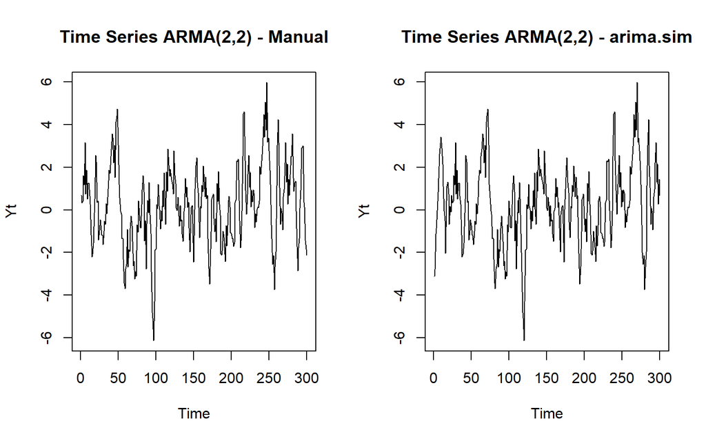

```r
par(mfrow = c(1, 2))
ts.plot(arma22_manual, main = "Time Series ARMA(2,2) - Manual", ylab = "Yt")
ts.plot(arma22_sim, main = "Time Series ARMA(2,2) - arima.sim", ylab = "Yt")
```

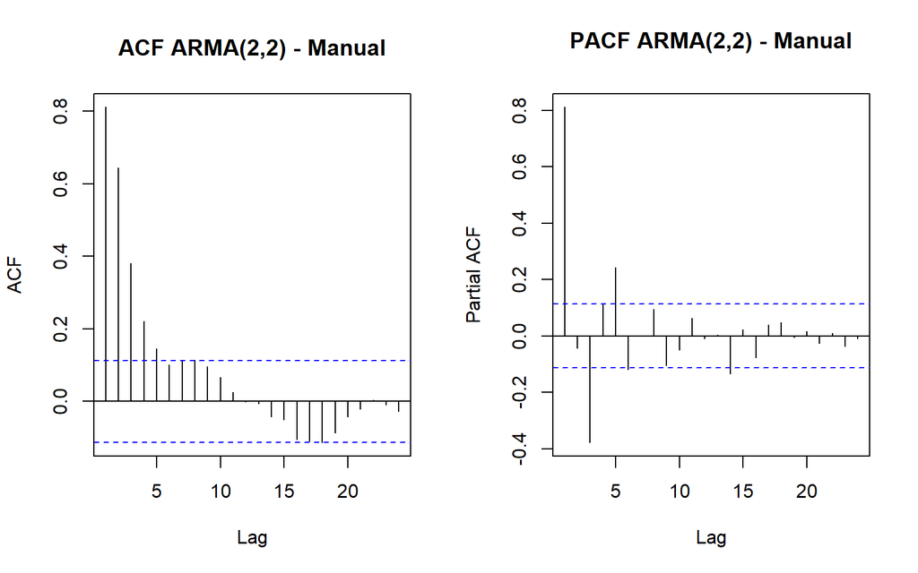

```r
par(mfrow = c(1, 2))
acf(arma22_manual, main = "ACF ARMA(2,2) - Manual")
pacf(arma22_manual, main = "PACF ARMA(2,2) - Manual")
```

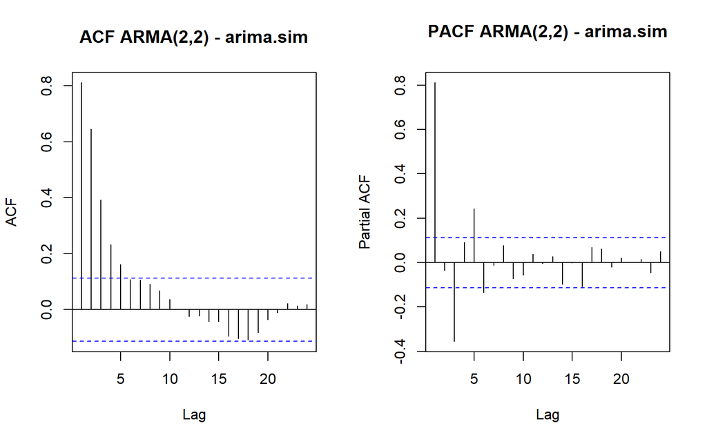

```r
par(mfrow = c(1, 2))
acf(arma22_sim, main = "ACF ARMA(2,2) - arima.sim")
pacf(arma22_sim, main = "PACF ARMA(2,2) - arima.sim")
```

```r
cat("EACF - Data Manual\n")
```

```
## EACF - Data Manual
```

```r
eacf(arma22_manual)
```

```
## AR/MA
##   0 1 2 3 4 5 6 7 8 9 10 11 12 13
## 0 x x x x x o o o o o o  o  o  o
## 1 o x o o o x o o o o o  o  o  o
## 2 o x o o o x o o o o o  o  o  o
## 3 x x o x o x o o o o o  o  o  o
## 4 x x o x o x o o o o o  o  o  o
## 5 x x x x o o o o o o o  o  o  o
## 6 o x o x o o o o o o o  o  o  o
## 7 o x o x o o o o o o o  o  o  o
```

```r
cat("\nEACF - Data arima.sim\n")
```

```
##
## EACF - Data arima.sim
```

```r
eacf(arma22_sim)
```

```
## AR/MA
##   0 1 2 3 4 5 6 7 8 9 10 11 12 13
## 0 x x x x x o o o o o o  o  o  o
## 1 o x o o o x o o o o o  o  o  o
## 2 o x o o o x o o o o o  o  o  o
## 3 x x o x o x o o o o o  o  o  o
## 4 x x o x o x o o o o o  o  o  o
## 5 x x o x x o o o o o o  o  o  o
## 6 x x o x x o o o o o o  o  o  o
## 7 x x x x x o o o o o o  o  o  o
```

**Identifikasi kestasioneran:** Kestasioneran proses ARMA(2,2) hanya ditentukan oleh komponen AR-nya karena bagian MA selalu stasioner. Sehingga syaratnya akar-akar $1-\phi_1 z - \phi_2 z^2 = 0$ harus berada di luar lingkaran satuan.

```r
akar_arma <- polyroot(c(1, -phi1, -phi2))
akar_arma
```

```
## [1]  1.311738+0i -3.811738+0i
```

```r
Mod(akar_arma)
```

```
## [1] 1.311738 3.811738
```

Karena parameter $\phi_1, \phi_2$ sama dengan Soal 2 dan modulus akar lebih besar dari 1, proses ARMA(2,2) ini **stasioner**. Pada plot ACF dan PACF, polanya tidak langsung *cut off* seperti AR maupun MA murni, melainkan meluruh (*tails off*) pada kedua plot.

## 3.3 Scatterplot $Y_t$ vs $Y_{t-1}$, $Y_{t-2}$, $Y_{t-3}$

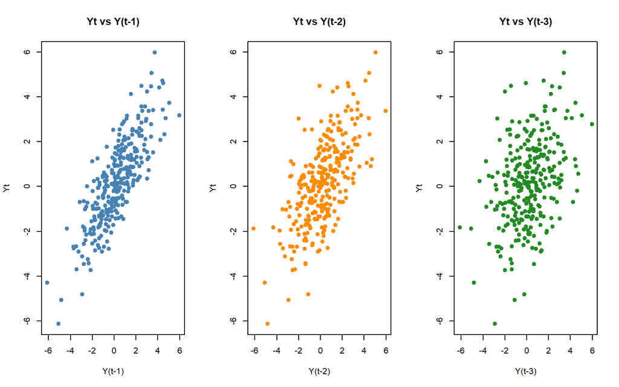

```r
Yt <- as.numeric(arma22_manual)
n_y <- length(Yt)

par(mfrow = c(1, 3))
plot(Yt[1:(n_y-1)], Yt[2:n_y], xlab = "Y(t-1)", ylab = "Yt",
     main = "Yt vs Y(t-1)", pch = 19, col = "steelblue")
plot(Yt[1:(n_y-2)], Yt[3:n_y], xlab = "Y(t-2)", ylab = "Yt",
     main = "Yt vs Y(t-2)", pch = 19, col = "darkorange")
plot(Yt[1:(n_y-3)], Yt[4:n_y], xlab = "Y(t-3)", ylab = "Yt",
     main = "Yt vs Y(t-3)", pch = 19, col = "forestgreen")
```

## 3.4 Autokorelasi: Empiris vs Teoritis

**Autokorelasi empiris (dari data bangkitan):**

```r
acf_arma_manual <- as.numeric(acf(arma22_manual, plot = FALSE, lag.max = 5)$acf)
acf_arma_sim    <- as.numeric(acf(arma22_sim, plot = FALSE, lag.max = 5)$acf)

cat("Panjang acf_arma_manual:", length(acf_arma_manual), "\n")
```

```
## Panjang acf_arma_manual: 5
```

```r
cat("Panjang acf_arma_sim   :", length(acf_arma_sim), "\n")
```

```
## Panjang acf_arma_sim   : 5
```

```r
lag_len <- min(length(acf_arma_manual), length(acf_arma_sim))

data.frame(
  Lag = 0:(lag_len - 1),
  ACF_Manual = round(acf_arma_manual[1:lag_len], 4),
  ACF_arima.sim = round(acf_arma_sim[1:lag_len], 4)
)
```

```
##   Lag ACF_Manual ACF_arima.sim
## 1   0     0.8115        0.8108
## 2   1     0.6437        0.6454
## 3   2     0.3813        0.3917
## 4   3     0.2216        0.2330
## 5   4     0.1456        0.1617
```

**Autokorelasi teoritis ARMA(2,2):**

```r
acf_teoritis_arma <- ARMAacf(ar = c(phi1, phi2), ma = c(theta1, theta2), lag.max = 5)
data.frame(Lag = 0:5, ACF_Teoritis = round(acf_teoritis_arma, 4))
```

```
##   Lag ACF_Teoritis
## 0   0       1.0000
## 1   1       0.8592
## 2   2       0.7492
## 3   3       0.5464
## 4   4       0.4231
## 5   5       0.3208
```

# Kesimpulan

| Proses | Sifat Stasioner | Pola ACF | Pola PACF |
| --- | --- | --- | --- |
| MA(2) | Selalu stasioner | *Cut off* setelah lag 2 | *Tails off* |
| AR(2) | Stasioner jika akar karakteristik di luar lingkaran satuan | *Tails off* | *Cut off* setelah lag 2 |
| ARMA(2,2) | Stasioner jika komponen AR memenuhi syarat kestasioneran | *Tails off* | *Tails off* |

Nilai autokorelasi empiris (dari data hasil simulasi) mendekati nilai autokorelasi teoritis, meskipun tidak identik karena adanya variasi acak (random error) dalam proses pembangkitan data.